## README

Classification assigns items in a collection to target categories or classes. Its goal is to accurately predict the target class for each case in the data. One example where a classification model could be used is to identify loan applicants as low, medium, or high credit risks.

This analysis focuses classification approach using Decision Trees. A decision tree is a tool that uses a tree-like model of decisions and their possible outcomes. Each node represents a test on an attribute and each branch represents an outcome of that test. This assignment requires using decision tree (ctree) analysis as a classification tool to be applied to a data mining study within your domain of interest using R and RStudio. You need to provide a report on this.

# Using decision tree to classify the contraceptive method used by women

By leveraging decision tree modeling, we aim to uncover the most influential factors that contribute to the choice of contraceptive method among women. This can help healthcare providers tailor their counseling and support services, empower women in addressing barriers to contraception access and utilization. In summary, the decision tree approach is a well-founded and practical choice for this analysis, given its ability to provide actionable insights into a complex and important public health issue.

# Understanding the Data

The dataset for this was selected from the module’s recommended datasets list. It is a subset of the 1987 National Indonesia Contraceptive Prevalence Survey. The samples are married women who were either not pregnant or do not know if they were at the time of interview. Here is the Definitions of the columns of the data.

Description of Data Variables Variable Name Code Description Wife’s age Numerical Age of the wife Wife’s education Categorical 1=low, 2, 3, 4=high Education level of wife Husband’s education Categorical 1=low, 2, 3, 4=high Education level of husband Number of children ever born Numerical Number of children ever born by the wife Wife’s religion Binary 0=non-Islam, 1=Islam Religion of wife Wife’s now working Binary 0=Yes, 1=No Occupation status of wife Husband’s occupation Categorical 1, 2, 3, 4 Occupation status of husband Standard-of-living index Categorical 1=low, 2, 3, 4=high Living status Media exposure Binary 0=Good, 1=Not good Exposure to media/ICT Contraceptive method used Class attribute 1=No-use, 2=Long-term, 3=Short-term Choice of contraceptive method by the wife

# Exploratory Analysis

Using the ‘str’ function, it was observed that the variables in the dataset consist of integers. The summary function was used to obtain the minimum and maximum, as well as measures of central tendency (mean, median) and spread (1st and 3rd quartiles) for each of these variables. Attempt was made to create a new binary variable for the wife age and number of children i.e., ‘WifeAge’ and ‘NumChildren’ based on the condition of the wife’s age being greater than 25 and number of children being greater than 4. The frequency table for this new variable to count the occurrences of “Yes” and “No” values is shown below.

```
##   WifeAge WifeEducation HusbandEducation NumChildren WifeReligion WifeWorking
## 1      24             2                3           3            1           1
## 2      45             1                3          10            1           1
## 3      43             2                3           7            1           1
## 4      42             3                2           9            1           1
## 5      36             3                3           8            1           1
## 6      19             4                4           0            1           1
##   HusbandOccupation LivingStandardIndex MediaExposure ContraceptiveMethod
## 1                 2                   3             0                   1
## 2                 3                   4             0                   1
## 3                 3                   4             0                   1
## 4                 3                   3             0                   1
## 5                 3                   2             0                   1
## 6                 3                   3             0                   1
```

```
##     WifeAge      WifeEducation   HusbandEducation  NumChildren
##  Min.   :16.00   Min.   :1.000   Min.   :1.00     Min.   : 0.000
##  1st Qu.:26.00   1st Qu.:2.000   1st Qu.:3.00     1st Qu.: 1.000
##  Median :32.00   Median :3.000   Median :4.00     Median : 3.000
##  Mean   :32.54   Mean   :2.959   Mean   :3.43     Mean   : 3.261
##  3rd Qu.:39.00   3rd Qu.:4.000   3rd Qu.:4.00     3rd Qu.: 4.000
##  Max.   :49.00   Max.   :4.000   Max.   :4.00     Max.   :16.000
##   WifeReligion     WifeWorking     HusbandOccupation LivingStandardIndex
##  Min.   :0.0000   Min.   :0.0000   Min.   :1.000     Min.   :1.000
##  1st Qu.:1.0000   1st Qu.:0.0000   1st Qu.:1.000     1st Qu.:3.000
##  Median :1.0000   Median :1.0000   Median :2.000     Median :3.000
##  Mean   :0.8506   Mean   :0.7495   Mean   :2.138     Mean   :3.134
##  3rd Qu.:1.0000   3rd Qu.:1.0000   3rd Qu.:3.000     3rd Qu.:4.000
##  Max.   :1.0000   Max.   :1.0000   Max.   :4.000     Max.   :4.000
##  MediaExposure   ContraceptiveMethod
##  Min.   :0.000   Min.   :1.00
##  1st Qu.:0.000   1st Qu.:1.00
##  Median :0.000   Median :2.00
##  Mean   :0.074   Mean   :1.92
##  3rd Qu.:0.000   3rd Qu.:3.00
##  Max.   :1.000   Max.   :3.00
```

```
## 'data.frame':    1473 obs. of  10 variables:
##  $ WifeAge            : int  24 45 43 42 36 19 38 21 27 45 ...
##  $ WifeEducation      : int  2 1 2 3 3 4 2 3 2 1 ...
##  $ HusbandEducation   : int  3 3 3 2 3 4 3 3 3 1 ...
##  $ NumChildren        : int  3 10 7 9 8 0 6 1 3 8 ...
##  $ WifeReligion       : int  1 1 1 1 1 1 1 1 1 1 ...
##  $ WifeWorking        : int  1 1 1 1 1 1 1 0 1 1 ...
##  $ HusbandOccupation  : int  2 3 3 3 3 3 3 3 3 2 ...
##  $ LivingStandardIndex: int  3 4 4 3 2 3 2 2 4 2 ...
##  $ MediaExposure      : int  0 0 0 0 0 0 0 0 0 1 ...
##  $ ContraceptiveMethod: int  1 1 1 1 1 1 1 1 1 1 ...
```

```
##
##   No  Yes
##  356 1117
```

```
##
##   No  Yes
## 1105  368
```

# Variable Analysis

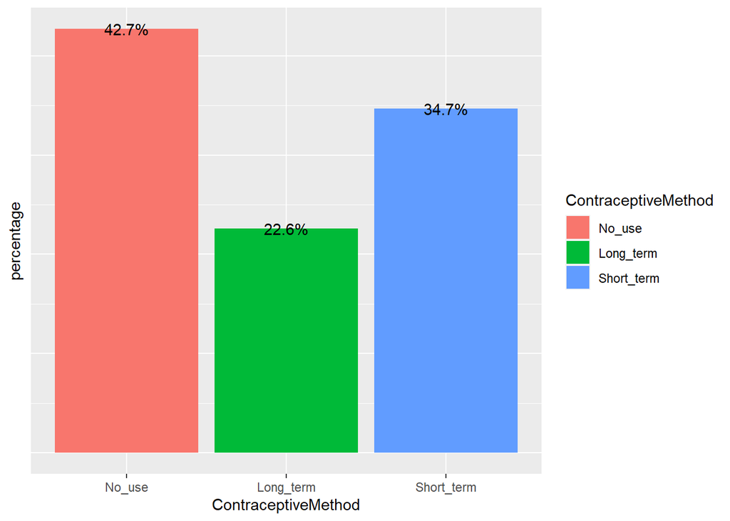

[figure not shown]

[figure not shown]

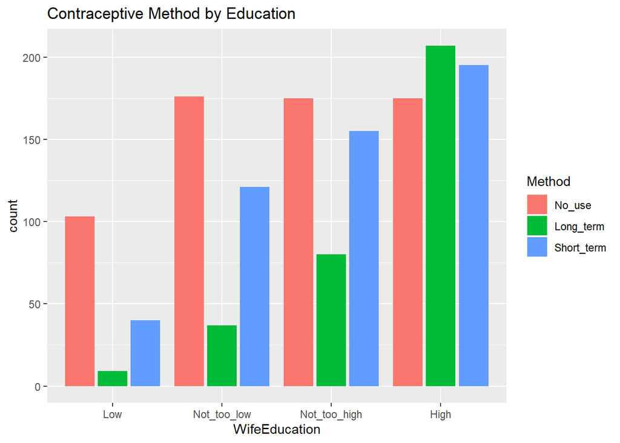

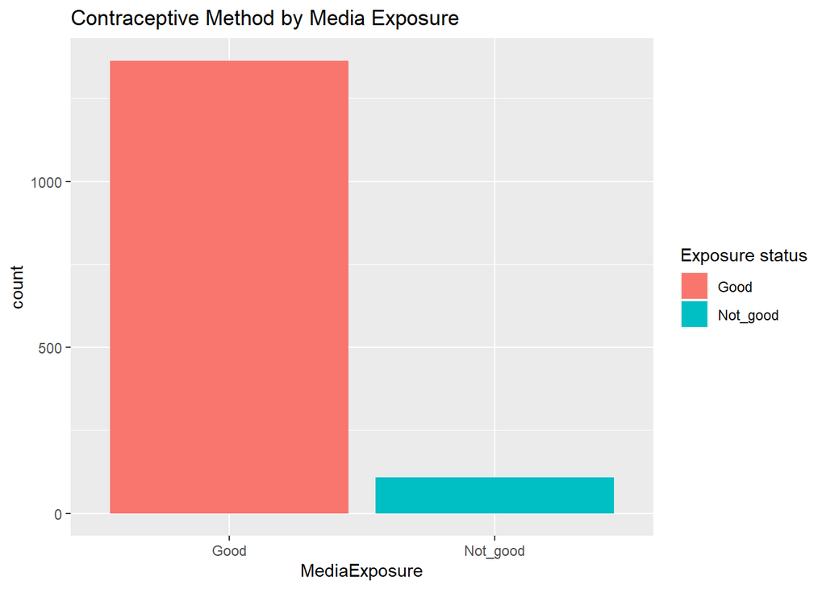

[output not shown]